# Predicting survival on the Titanic

Goal of this Kaggle competition is to predict survival of a passengers on the titanic by applying supervised learning on a training set provided to us.

**VARIABLE DESCRIPTIONS:**

1. survival - Survival (0 = No; 1 = Yes)
2. pclass - Passenger Class (1 = 1st; 2 = 2nd; 3 = 3rd)
3. name - Name
4. sex - Sex
5. age - Age
6. sibsp - Number of Siblings/Spouses Aboard
7. parch - Number of Parents/Children Aboard
8. ticket - Ticket Number
9. fare - Passenger Fare
10. cabin - Cabin
11. embarked - Port of Embarkation (C = Cherbourg; Q = Queenstown; S = Southampton)

```python
import numpy as np
import pandas as pd
import pylab as P
import decimal
import matplotlib.pyplot as plt
import csv
from sklearn.ensemble import RandomForestClassifier
from sklearn.linear_model import LogisticRegression
from sklearn import svm
from sklearn.cross_validation import train_test_split
from sklearn import cross_validation
%matplotlib inline
```

```python
# Load data into a Pandas data frame
filename = '/Users/manishkurse/Documents/DataScience/DataScienceProjects/Kaggle/TitanicShipwreck/train.csv'

# # Create a data frame reading from CSV file
df = pd.read_csv(filename, header=0)

# View the data
df.head(4)
```

|  | PassengerId | Survived | Pclass | Name | Sex | Age | SibSp | Parch | Ticket | Fare | Cabin | Embarked |
| --- | --- | --- | --- | --- | --- | --- | --- | --- | --- | --- | --- | --- |
| 0 | 1 | 0 | 3 | Braund, Mr. Owen Harris | male | 22 | 1 | 0 | A/5 21171 | 7.2500 | NaN | S |
| 1 | 2 | 1 | 1 | Cumings, Mrs. John Bradley (Florence Briggs Th... | female | 38 | 1 | 0 | PC 17599 | 71.2833 | C85 | C |
| 2 | 3 | 1 | 3 | Heikkinen, Miss. Laina | female | 26 | 0 | 0 | STON/O2. 3101282 | 7.9250 | NaN | S |
| 3 | 4 | 1 | 1 | Futrelle, Mrs. Jacques Heath (Lily May Peel) | female | 35 | 1 | 0 | 113803 | 53.1000 | C123 | S |

## Clean data and Feature Engineering

Here are some of the changes that were made:

Filing missing ages with median values for that gender and Class

Mapping categorical variables to numerical categories

Using median values for Fare where they are missing

Continuous variable Fare being divided into discrete categories

Creating new binary categorical variable indicating whether the ticket is a number only or there are alphabets in it

```python
# Clean data : remove missing data and create new variables
def clean_data(df):
    # Mapping gender data to a numerical 0,1
    df['Gender'] = df['Sex'].map( {'female': 0, 'male': 1} ).astype(int)

    # Fill missing age values with median in the corresponding Pclass,gender and create a new variable
    df['AgeFill'] = df['Age']

    median_ages = np.zeros((2,3))
    for i in range(0,2):
        for j in range(0,3):
            median_ages[i,j] = df[(df['Gender']==i)&(df['Pclass']==j+1)]['Age'].dropna().median()
            df['AgeFill'].loc[(df['Gender']==i)&(df['Pclass']==j+1)&(df['Age'].isnull())] =median_ages[i,j]

    # Create a new variable family size which is sum of siblings, parents and children
    df['FamilySize'] = df['SibSp'] + df['Parch']

    # Fill missing values for Embarked with the mode
    df['Port']  = df['Embarked']
    df.Port = df.Port.fillna(df.Port.mode()[0])

    # Mapping port to numeric data 0,1,2
    df['Port'] = df['Port'].map( {'C': 0, 'Q': 1, 'S': 2} ).astype(int)

    # Fill missing values of fare with median value
    df.Fare[df.Fare.isnull()] = df.Fare.median()

    df['Ticket_AlphaNum'] = np.zeros(df.shape[0])
    for i in range(df.shape[0]):
        if df.Ticket[i][0].isalpha():
            df.Ticket_AlphaNum[i] = 1
        else:
            df.Ticket_AlphaNum[i] = 0


    # Categorize the Fares to form groups.
    num_fare_groups = 6
    df['FareCat'] = df['Fare']*-1
    # Use percentile to categorize the fares
    perc = np.linspace(0,100,num_fare_groups)


    for i in range(0,len(perc)-1):
        df['FareCat'][(df['Fare']>=np.percentile(df['Fare'],perc[i]))\
        & (df['Fare']<=np.percentile(df['Fare'],perc[i+1]))]=i

    # Remove features you don't plan to use
    df =df.drop(['Name', 'Sex', 'Ticket', 'Cabin', 'Embarked','Age'], axis=1)
    return df


# Convert dataframe to array
def get_array_from_dataframe(df,featureNames):
    df = df[featureNames]
    data = df.values
    data = data.astype(np.float)
    return data

# Clean the data. Filling nans
print(df.shape, ': Before cleaning')
df = clean_data(df)
df.head(3)
print(df.shape, ': After cleaning')
```

```
(891, 12) : Before cleaning
(891, 12) : After cleaning
```

## Exploratory Data Analysis

```python
# Understand the data
# See how many nans exist
print('Out of ',df.shape[0] * df.shape[1],' values, ',\
      (df.shape[0] * df.shape[1]) - df.count().sum(),' nans exist')
print(df.AgeFill.max(), 'is max age and', df.AgeFill.min(), 'is min age')
```

```
Out of  10692  values,  0  nans exist
80.0 is max age and 0.42 is min age
```

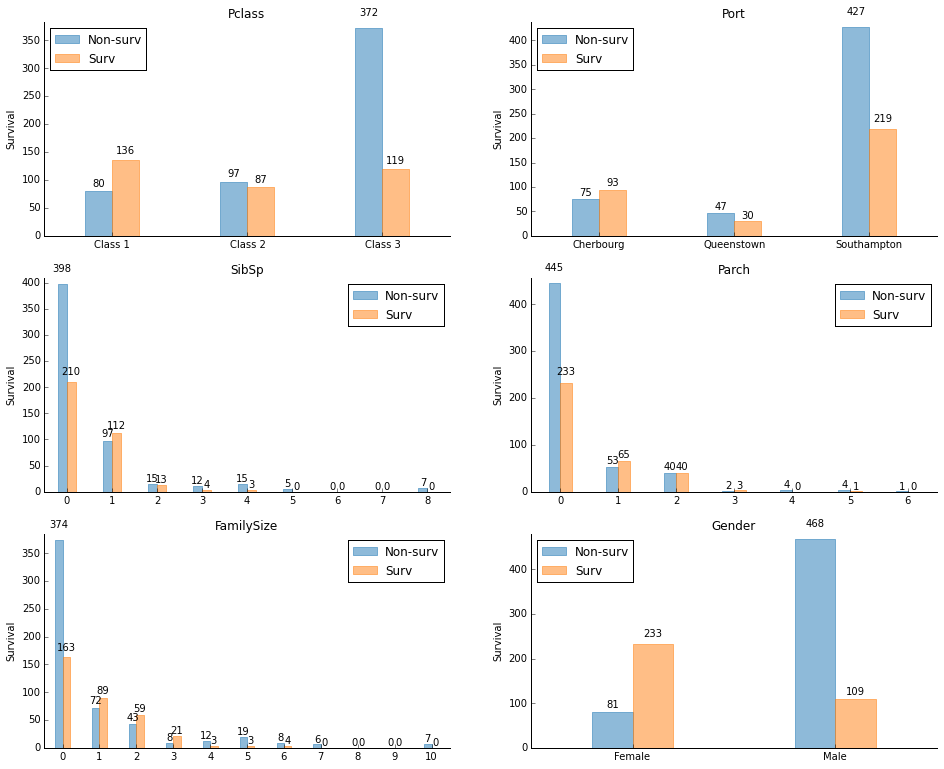

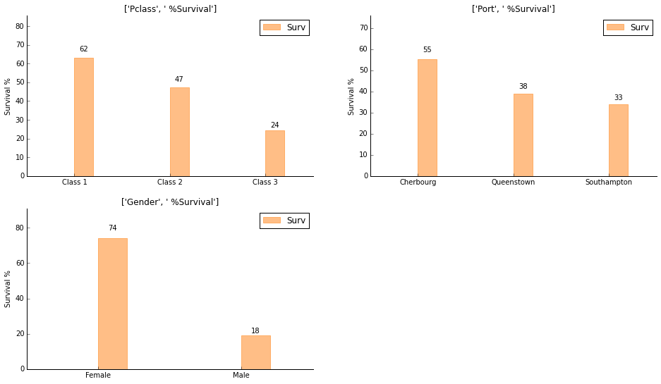

```python
def prepare_plot_area(ax):
    # Remove plot frame lines
    ax.spines["top"].set_visible(False)
    ax.spines["right"].set_visible(False)

    # X and y ticks on bottom and left
    ax.get_xaxis().tick_bottom()
    ax.get_yaxis().tick_left()

def autolabel(rects):
    # attach some text labels
    for rect in rects:
        height = rect.get_height()
        ax.text(rect.get_x()+rect.get_width()/2., 1.05*height, '%d'%int(height),
                ha='center', va='bottom')
def autolabel(rects,ax):
    # attach some text labels
    for rect in rects:
        height = rect.get_height()
        ax.text(rect.get_x()+rect.get_width()/2., 1.05*height, '%d'%int(height),\
                ha='center', va='bottom')

colrcode = [(31, 119, 180), (255, 127, 14),\
             (44, 160, 44), (214, 39, 40), \
             (148, 103, 189),  (140, 86, 75), \
             (227, 119, 194), (127, 127, 127), \
             (188, 189, 34), (23, 190, 207)]

for i in range(len(colrcode)):
    r, g, b = colrcode[i]
    colrcode[i] = (r / 255., g / 255., b / 255.)

def plot_survival(df,label_name,label_values,ax,per_flag,label_values_names_list):
    ind = [0,1]
    alpha_plots= .5
    label_values = np.array(label_values) # Labels which you want to plot
    p = np.zeros((len(label_values),2)) # 2 columns for survived no and yes.
    for x in range(len(label_values)):
        count_label = df[df[label_name] == label_values[x]]['Survived'].count()
        if per_flag == True:
            if count_label != 0:
                p[x,1] = df[df[label_name] == label_values[x]]['Survived'].sum()/count_label*100
                p[x,0] = 100-p[x,1]
            else:
                p[x,0] = 0
                p[x,1] = 0
        else:
            p[x,1] = df[df[label_name] == label_values[x]]['Survived'].sum()
            p[x,0] = count_label-p[x,1]

    # Plot the 2 groups: No survived and survived.
    rect_width = .2
    if per_flag == False:
        rects_surv_no = plt.bar(label_values-rect_width,p[:,0],width=rect_width,\
                                alpha = alpha_plots, color=colrcode[0],edgecolor = colrcode[0],label = 'Non-surv')
        autolabel(rects_surv_no,ax)
        plt.ylabel('Survival')
        plt.title(label_name)
    else:
        plt.ylabel('Survival %')
        plt.title([label_name,' %Survival'])

    rects_surv_yes = plt.bar(label_values,p[:,1],width=.2,alpha = alpha_plots, color=colrcode[1],edgecolor = colrcode[1],label = 'Surv')

    plt.xticks(label_values,label_values_names_list)
    plt.xlim(np.min(label_values)-.5,np.max(label_values)+.5)
    plt.ylim(0,np.max(p)+10)
    autolabel(rects_surv_yes,ax)
    plt.legend(loc = 'best')


def plot_raw_data_ver1(df):

    # Figure object parameters
    alpha_plots= 1

    label_name_list = ['Pclass','Port','SibSp','Parch','FamilySize','Gender']
    label_values_list = [[1,2,3],[0,1,2],list(range(df.SibSp.max()+1)),list(range(df.Parch.max()+1)),list(range(df.FamilySize.max()+1)),[0,1]]
    label_values_names_list = [['Class 1','Class 2','Class 3'],['Cherbourg','Queenstown','Southampton'],\
                               list(range(9)),list(range(7)),list(range(11)),['Female','Male']]


    fig = plt.figure(figsize=(16,13))
    for x in range(len(label_name_list)):
        ax = plt.subplot(3,2,x+1)
        prepare_plot_area(ax)
        plot_survival(df,label_name_list[x],label_values_list[x],ax,False,label_values_names_list[x])

    label_name_list_subset = ['Pclass','Port','Gender']
    label_values_list_subset = [[1,2,3],[0,1,2],[0,1]]
    label_values_names_list_subset = [['Class 1','Class 2','Class 3'],['Cherbourg','Queenstown','Southampton'],\
                               ['Female','Male']]


    fig = plt.figure(figsize=(16,9))
    for x in range(len(label_name_list_subset)):
        ax = plt.subplot(2,2,x+1)
        prepare_plot_area(ax)
        plot_survival(df,label_name_list_subset[x],label_values_list_subset[x],ax,True,label_values_names_list_subset[x])


plot_raw_data_ver1(df)
```

### Insight on data:

Based on the above plots we can see that:

A much larger % of women survived compared to males. This makes sense since it is known that women and children were asked to board the lifeboats first.

A much larger % of 1st Class passengers survived compared to 3rd class.

Looks like passengers embarking in Cherbourg had a larger percentage of survival.

## Performing Machine Learning on the Cleaned Dataset

Random Forest Classification is performed on a select set of features. scikit-learn is used for this. A 10-fold Cross Validation is performed to select parameters of the Random Forest Classifier.

```
The mean score on the training dataset is :  0.86
The mean score on the cross-validation dataset is :  0.83
```

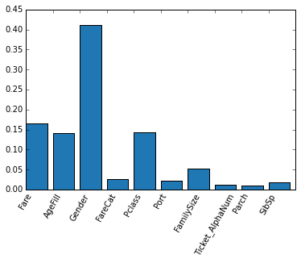

```python
##Training
def normalizeFeatures(dataArr):
    return((dataArr - np.mean(dataArr))/(np.std(dataArr)))

featureNames = ['Survived','Fare','AgeFill','Gender','FareCat','Pclass','Port','FamilySize','Ticket_AlphaNum','Parch','SibSp']
train_data = get_array_from_dataframe(df,featureNames)
# cv_data = get_array_from_dataframe(cv_df,featureNames)
features2Normalize = [1,2]
for count in range(0,len(features2Normalize)):
    train_data[:,features2Normalize[count]] = normalizeFeatures(train_data[:,features2Normalize[count]])

# Number of samples in the training data
num_samples = train_data.shape[0]

# Create the random forest object which will include all the parameters
# for the fit
num_folds = 10

classifier  = RandomForestClassifier(n_estimators = 100,criterion = "entropy", max_depth=10, max_features = 7,min_samples_leaf = 6, max_leaf_nodes = 20, oob_score=True)

score_cv = np.zeros(num_folds)
score_train = np.zeros(num_folds)
num_cv_sam = np.zeros(num_folds)
all_out = np.ones((num_cv_sam.shape[0],num_samples))*999

# Get k-fold cross-validation indices
kf = cross_validation.KFold(train_data.shape[0], n_folds=num_folds,shuffle = True)

count = 0
for train_index, cv_index in kf:
    # Fit the training data to the Survived labels and create the decision trees
    num_cv_sam[count] = len(cv_index)
    classifier  = classifier.fit(train_data[train_index,1::],train_data[train_index,0])
    score_cv[count] = classifier.score(train_data[cv_index,1::],train_data[cv_index,0])
    score_train[count] = classifier.score(train_data[train_index,1::],train_data[train_index,0])
    outp = classifier.predict(train_data[:,1::])
    all_out[count,0::] = np.array(outp)
    count = count+1

print('The mean score on the training dataset is : ',np.around(np.mean(score_train),2))
print('The mean score on the cross-validation dataset is : ',np.around(np.mean(score_cv),2))
plt.figure()
plt.bar(list(range(len(classifier.feature_importances_))),classifier.feature_importances_,color = colrcode[0])
p = plt.xticks(list(range(len(classifier.feature_importances_))),['Fare','AgeFill','Gender','FareCat','Pclass','Port','FamilySize','Ticket_AlphaNum','Parch','SibSp'],rotation=60)
```

Based on the feature importances it is clear that gender was the biggest factor followed by Fare, age and Class. The training and 10-fold cross validation errors being almost equivalent shows that the model is not overfitting.

```python
# Get Test data from the csv file
filename = '/Users/manishkurse/Documents/DataScience/DataScienceProjects/Kaggle/TitanicShipwreck/test.csv'
# Create a data frame reading from CSV file
df_test = pd.read_csv(filename, header=0)
clean_data(df_test)

featureNames = featureNames[1::]
test_data = get_array_from_dataframe(df_test,featureNames)
features2Normalize = [0,1] # Since survival is not there
for count in range(0,len(features2Normalize)):
    test_data[:,features2Normalize[count]] = normalizeFeatures(test_data[:,features2Normalize[count]])

passengerid = get_array_from_dataframe(df_test,'PassengerId')

# Take the same decision trees and run it on the test data
classifier  = classifier.fit(train_data[:,1::],train_data[:,0])
output = classifier.predict(test_data)
num_test_data = np.size(test_data[:,0])
pred = np.zeros((num_test_data,2),dtype = np.int)
pred[:,0] = passengerid
pred[:,1] = output

headers = ['PassengerId','Survived']
f= open('/Users/manishkurse/Documents/DataScience/DataScienceProjects/Kaggle/TitanicShipwreck/random_forest_py.csv','w')
f_csv = csv.writer(f)
f_csv.writerow(headers)
f_csv.writerows(pred)
f.close()
print('CSV file created!')
```

```
CSV file created!
```